# TPC 4-Estatística computacional

João Francisco Botas, nº104782

24/09/2022

# Variavéis aleatórias

## Exercício 1

> Considere que a procura diária, num certo supermercado, do novo artigo de limpeza, X, lançado no mês passado pela empresa TudoBrilha, pode ser modelizada através de uma variável aleatória com distribuição de Poisson de média 3,1.

### a)

> Qual a probabilidade de, num dia, a procura de X ser no máximo 3?

Designemos a variável aleatória de interesse de $X_1$ - procura diária do novo artigo de limpeza, com proporcionalidade de efeito de 3.1. Como pretende-se saber a probabilidade da procura diária ser no máximo 3, conseguimos escrever isso da seguinte forma $P[X_1 \le 3]$. Esta expressão irá equivaler a algo do género, pela fórmula de Poisson:

$\!f(x)= \frac{e^{-\lambda}{\lambda^x}}{x!}$, em que $\lambda=3.1$ e $x\in [0,3]$, ou seja, onde x adquire os valores de 0 a 3, inclusive. A fórmula de cálculo exato será de:

$$\!f(x)=
\frac{e^{-3.1}{3.1^x}}{x!}\Longleftrightarrow{\displaystyle \sum
_{i\mathop {=0} }^{3}g(x_{i})}$$

Para se chegar perto do valor da probabilidade, será realizado uma simulação com a função *rpois* do R.

```r
rand_a <- rpois(10000,3.1)
simA <- length(which(rand_a<=3))/length(rand_a)
simA
```

```
## [1] 0.6199
```

Feita a simulação concluímos que o valor da probabilidade pedida ronda o valor seguinte:0.6199. Agora, calculemos pela fórmula de Poisson, utilizando o comando *ppois*.

```r
max_3 <- ppois(3,3.1,lower.tail=TRUE)
max_3
```

```
## [1] 0.6248399
```

Como será expectável, o valor da probabilidade da função *ppois* vai obter um valor próximo ao da simulação; **0.6248** $\approx$ 0.6199. $P[X_1 \le 3]={0.6248}$

### b)

> Qual a probabilidade de, numa semana (7 dias) a procura ser no mínimo 22?

Designemos a variável de interesse $X_2$ - procura semanal do novo artigo de limpeza. A proporcionalidade de efeito ($\lambda$) é dada em termos de procura *diária*, ou seja, para passar a procura para *semanal* é necessário fazer o seguinte:

$${\displaystyle {\frac
{3.1}{\lambda_{novo}}}={\frac {1}{7}}}\Longleftrightarrow
\lambda_{novo}=3.1\times7(dias)=21.7$$
Com a proporcionalidade de efeito ($\lambda =21.7$), já é possível calcular $P[X_2 \ge 22]$, que corresponde à procura semanal ser no mínimo 22. O valor em termos matemáticos poderá ser calculado através das fórmulas seguintes:

$\!g(x)= \frac{e^{-\lambda}{\lambda^x}}{x!}$, em que $\lambda=21.7$ e $x\in [22,+\infty[$, ou seja, onde x adquire os valores de 22 a $+\infty$. A fórmula de cálculo exato será:

$$\!g(x)=
\frac{e^{-21.7}{21.7^x}}{x!}\Longleftrightarrow{\displaystyle \sum
_{i\mathop {=22} }^{N}g(x_{i})}$$
, em que $N$ é um número muito grande

Tal como na *alínea a)* irá recorrer-se a uma simulação de maneira a mostrar um valor próximo ao real.

```r
rand_b <- rpois(10000,21.7)
simB <- length(which(rand_b>=22))/length(rand_b)
simB
```

```
## [1] 0.5033
```

A simulação chegou ao valor seguinte:0.5033. Com isto, é possível concluir que o valor real tomará um valor parecido a este. Calculemos recorrendo à função *ppois*.

```r
min_22 <- ppois(21,21.7,lower.tail = FALSE)
min_22
```

```
## [1] 0.5027808
```

**NOTA**: para calcular $P[X_2 \ge 22]$ foi necessário utilizar *lower.tail=FALSE* para inverter o sinal, mas utilizou-se a seguinte condição: $P[X_2>21]=P[X_2 \ge 22]$

### c)

> Qual a probabilidade de, em 7 dias, ocorrerem no máximo 4 dias onde a procura diária é no máximo 3?

Consideremos a variável de interesse para esta condição de $X_3$ - nº de dias onde a procura diária é no máximo 3, em 7 dias(semanalmente). O modelo probabilístico poderá ser escrito na forma de $P[X_3 \le 4]$ : procura diária ser no máximo 3, onde o sucesso é ocorrer ou não ocorrer a procura diária. Em termos matemáticos, esta condição poderá ser calculada utilizando a seguinte fórmula:

${\displaystyle h(x;n,p)={C^n_x}\times p^{x}\times (1-p)^{n-x}\,}$, onde $n=7, p=P[X_1 \le 3]={0.6248}, x\in[0,4]$, em que n e p são valores constantes, e já calculados anteriormente, e onde x varia entre 0 e 4, inclusive. Portanto, teremos a fórmula simplicada seguinte:

$${\displaystyle h(x)={C^7_x}\times
0.6248^{x}\times (1-0.6248)^{7-x}\,}\Longleftrightarrow{\displaystyle
\sum _{i\mathop {=0} }^{4}h(x_{i})}$$

Mais uma vez, irá recorrer-se a uma simulação para calcular um valor próximo ao exato.

```r
rand_c <- rbinom(10000,size=7,max_3)
simC <- length(which(rand_c<=4))/length(rand_c)
simC
```

```
## [1] 0.5235
```

Com este output, será possível concluir que o valor exato estará próximo a este: 0.5235.

```r
max_4 <- pbinom(4,size=7,prob=max_3,lower.tail = TRUE)
max_4
```

```
## [1] 0.5250135
```

Assim, podemos concluir que $P[X_3 \le 4]={0.525}$; valor próximo ao simulado **0.525** $\approx$ 0.5235.

## Exercício 2

> Certa fábrica possui um depósito de combustível que é completamente atestado no primeiro dia de cada mês. O volume de combustível (em milhões de litros) consumido mensalmente nessa fábrica é uma variável aleatória com a seguinte função densidade: $f(x)={3(1-x)^2=3(1-2x+x^2)}$, $0<x<1$.

### a)

> Represente graficamente a função densidade indicada.

Função de densidade de volume de combustível consumido mensalmente, em milhões de litros:

$f(x)={3(1-x)^2}$, $0<x<1$

Para desenhar a função acima recorre-se ao comando *plot*, onde são dados vários parâmetros, e, em seguida, utiliza-se o *points* de forma a representar na função os intervalos em que está contida, $0<x<1$.

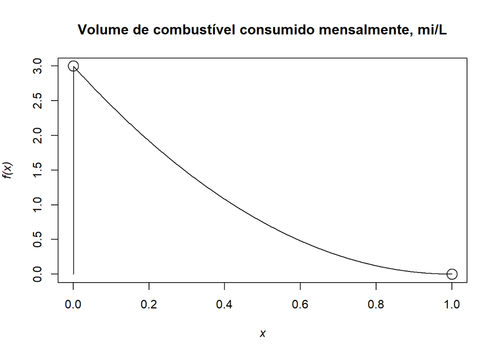

```r
fx <- function(x){ifelse((0<x & x<1), 3*(1-2*x+x*x), 0)}
plot(fx,0,1,xlim=c(0,1),n=1001,main="Volume de combustível consumido mensalmente, mi/L",xlab=substitute(paste(italic("x"))),ylab=substitute(paste(italic("f(x)"))))
points(x = c(0,1),
       y = c(3,fx(1)),
       pch = 1,
       col = "black",cex=2) # 0<x<1
```

Como output foi desenhada a função de densidade pretendida.

### b)

> Qual a probabilidade de, em certo mês, o consumo se situar entre 0,2 e 0,8 milhões de litros?

Pretende-se calcular a probabilidade em que o consumo se situa entre 0.2 e 0.8 mi/L; chamemos-lhe de acontecimento I. Para tal, recorre-se ao seguinte integral:

${{I=\displaystyle\int\nolimits_{0.2}^{0.8}} {3(1-x)^2}} dx$

Irá ser desenhado o gráfico com a área pretendida, utilizando os comandos *points* e *polygon*. Depois será calculado o integral com a função *integrate* do R.

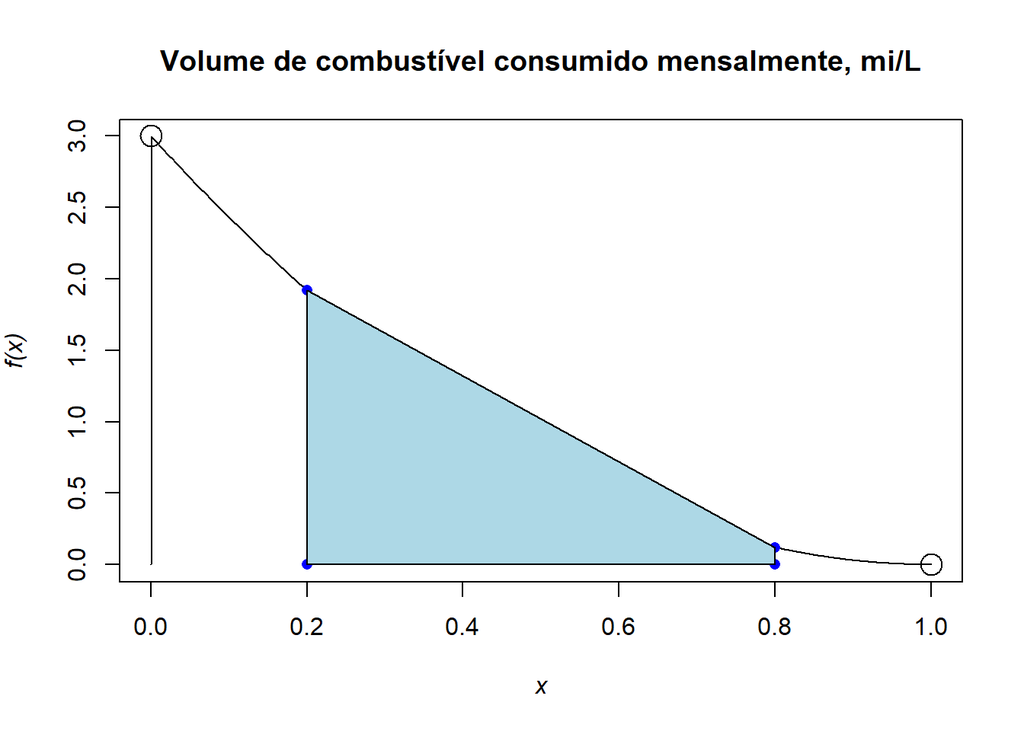

```r
plot(fx,0,1,xlim=c(0,1),n=1001,main="Volume de combustível consumido mensalmente, mi/L",xlab=substitute(paste(italic("x"))),ylab=substitute(paste(italic("f(x)"))))
points(x = c(0,1),
       y = c(3,fx(1)),
       pch = 1,
       col = "black",cex=2) # 0<x<1
points(x = c(.2,.8,.8,.2),
       y = c(0,0,fx(.8),fx(.2)),
       pch = 16,
       col = "blue")
polygon(c(.2,.8,.8,.2),c(0,0,fx(.8),fx(.2)),col="light blue")
```

```r
# para obter a probabilidade basta calcular o integral
ProbI <- integrate(fx, .2, .8, abs.tol = TRUE)
cat("A probabilidade do consumo se situar entre 0.2 e 0.8 mi/L, em certo mês, será de",ProbI$value,".")
```

```
## A probabilidade do consumo se situar entre 0.2 e 0.8 mi/L, em certo mês, será de 0.504 .
```

Assim, concluiu-se que a probabilidade do acontecimento $I$= **0.504**.

### c)

> Calcule o consumo médio mensal.

Para calcular o valor médio mensal irá calcular-se o integral no intervalo: $0<x<1$, a partir de $xf(x)$.

```r
xfx <- function(x){ifelse((0<x & x<1), 3*x*(1-2*x+x*x), 0)}
E_X=integrate(xfx, 0, 1)
cat("O consumo médio mensal é de",E_X$value,"mi/L.")
```

```
## O consumo médio mensal é de 0.25 mi/L.
```

Como output foi retornado o valor médio mensal; ${\displaystyle\int\limits_{0}^{1}}{xf(x)} dx$= **0.25**.